# FordGoBike 2017

## Preliminary Wrangling

This document explores a dataset containing the movement and rentment data of the FordGoBike in the Bay-Area.

```python
# import all packages and set plots to be embedded inline
import numpy as np
import pandas as pd
import matplotlib.pyplot as plt
import seaborn as sb

%matplotlib inline
```

```python
ford_bikes=pd.read_csv('2017-fordgobike-tripdata.csv')
```

```python
# high-level overview of data shape and composition
print(ford_bikes.shape)
print(ford_bikes.dtypes)
print(ford_bikes.head(10))
```

```
(519700, 15)
duration_sec                 int64
start_time                  object
end_time                    object
start_station_id             int64
start_station_name          object
start_station_latitude     float64
start_station_longitude    float64
end_station_id               int64
end_station_name            object
end_station_latitude       float64
end_station_longitude      float64
bike_id                      int64
user_type                   object
member_birth_year          float64
member_gender               object
dtype: object
   duration_sec                start_time                  end_time  \
0         80110  2017-12-31 16:57:39.6540  2018-01-01 15:12:50.2450
1         78800  2017-12-31 15:56:34.8420  2018-01-01 13:49:55.6170
2         45768  2017-12-31 22:45:48.4110  2018-01-01 11:28:36.8830
3         62172  2017-12-31 17:31:10.6360  2018-01-01 10:47:23.5310
4         43603  2017-12-31 14:23:14.0010  2018-01-01 02:29:57.5710
5          9226  2017-12-31 22:51:00.9180  2018-01-01 01:24:47.1660
6          4507  2017-12-31 23:49:28.4220  2018-01-01 01:04:35.6190
7          4334  2017-12-31 23:46:37.1960  2018-01-01 00:58:51.2110
8          4150  2017-12-31 23:37:07.5480  2018-01-01 00:46:18.3080
9          4238  2017-12-31 23:35:38.1450  2018-01-01 00:46:17.0530

   start_station_id                                 start_station_name  \
0                74                              Laguna St at Hayes St
1               284  Yerba Buena Center for the Arts (Howard St at ...
2               245                             Downtown Berkeley BART
3                60                               8th St at Ringold St
4               239                      Bancroft Way at Telegraph Ave
5                30     San Francisco Caltrain (Townsend St at 4th St)
6               259                            Addison St at Fourth St
7               284  Yerba Buena Center for the Arts (Howard St at ...
8                20    Mechanics Monument Plaza (Market St at Bush St)
9                20    Mechanics Monument Plaza (Market St at Bush St)
```

[output cut: 21 more lines]

```
7  Yerba Buena Center for the Arts (Howard St at ...             37.784872
8    Mechanics Monument Plaza (Market St at Bush St)             37.791300
9    Mechanics Monument Plaza (Market St at Bush St)             37.791300

   end_station_longitude  bike_id   user_type  member_birth_year member_gender
0            -122.415929       96    Customer             1987.0          Male
1            -122.426614       88    Customer             1965.0        Female
2            -122.267764     1094    Customer                NaN           NaN
3            -122.408445     2831    Customer                NaN           NaN
4            -122.265896     3167  Subscriber             1997.0        Female
5            -122.395282     1487    Customer                NaN           NaN
6            -122.299371     3539    Customer             1991.0        Female
7            -122.400876     1503    Customer                NaN           NaN
8            -122.399051     3125    Customer                NaN           NaN
9            -122.399051     2543    Customer                NaN           NaN
```

```python
ford_bikes.info()
```

```
<class 'pandas.core.frame.DataFrame'>
RangeIndex: 519700 entries, 0 to 519699
Data columns (total 15 columns):
duration_sec               519700 non-null int64
start_time                 519700 non-null object
end_time                   519700 non-null object
start_station_id           519700 non-null int64
start_station_name         519700 non-null object
start_station_latitude     519700 non-null float64
start_station_longitude    519700 non-null float64
end_station_id             519700 non-null int64
end_station_name           519700 non-null object
end_station_latitude       519700 non-null float64
end_station_longitude      519700 non-null float64
bike_id                    519700 non-null int64
user_type                  519700 non-null object
member_birth_year          453159 non-null float64
member_gender              453238 non-null object
dtypes: float64(5), int64(4), object(6)
memory usage: 59.5+ MB
```

```python
ford_bikes.user_type.value_counts()
```

```
Subscriber    409230
Customer      110470
Name: user_type, dtype: int64
```

## Asses

- start and endtime are objects
- missing values for birth_year and gender
- member_birth_year is float
- duration in seconds in minutes

## Clean

```python
ford_bikes_clean=ford_bikes.copy()
```

missing values for birth_year and gender

### Description

There are missing values for the bithy of year and gender, therefore columns withous this values will get dropped

### Code

```python
ford_bikes_clean.dropna(axis=0,inplace=True)
```

### Test

```python
ford_bikes_clean.info()
```

```
<class 'pandas.core.frame.DataFrame'>
Int64Index: 453159 entries, 0 to 519699
Data columns (total 15 columns):
duration_sec               453159 non-null int64
start_time                 453159 non-null object
end_time                   453159 non-null object
start_station_id           453159 non-null int64
start_station_name         453159 non-null object
start_station_latitude     453159 non-null float64
start_station_longitude    453159 non-null float64
end_station_id             453159 non-null int64
end_station_name           453159 non-null object
end_station_latitude       453159 non-null float64
end_station_longitude      453159 non-null float64
bike_id                    453159 non-null int64
user_type                  453159 non-null object
member_birth_year          453159 non-null float64
member_gender              453159 non-null object
dtypes: float64(5), int64(4), object(6)
memory usage: 55.3+ MB
```

start and endtime are objects

### Description

Change the data-type to timestamp of the column start_time and end_time

### Code

```python
ford_bikes_clean.start_time=pd.to_datetime(ford_bikes_clean.start_time)
ford_bikes_clean.end_time=pd.to_datetime(ford_bikes_clean.end_time);
```

### Test

```python
ford_bikes_clean.info()
```

```
<class 'pandas.core.frame.DataFrame'>
Int64Index: 453159 entries, 0 to 519699
Data columns (total 15 columns):
duration_sec               453159 non-null int64
start_time                 453159 non-null datetime64[ns]
end_time                   453159 non-null datetime64[ns]
start_station_id           453159 non-null int64
start_station_name         453159 non-null object
start_station_latitude     453159 non-null float64
start_station_longitude    453159 non-null float64
end_station_id             453159 non-null int64
end_station_name           453159 non-null object
end_station_latitude       453159 non-null float64
end_station_longitude      453159 non-null float64
bike_id                    453159 non-null int64
user_type                  453159 non-null object
member_birth_year          453159 non-null float64
member_gender              453159 non-null object
dtypes: datetime64[ns](2), float64(5), int64(4), object(4)
memory usage: 55.3+ MB
```

member_birth_year is float

### Description

change birth year to integer

### Code

```python
ford_bikes_clean.member_birth_year=ford_bikes_clean.member_birth_year.astype('int')
```

### Test

```python
ford_bikes_clean.info()
```

```
<class 'pandas.core.frame.DataFrame'>
Int64Index: 453159 entries, 0 to 519699
Data columns (total 15 columns):
duration_sec               453159 non-null int64
start_time                 453159 non-null datetime64[ns]
end_time                   453159 non-null datetime64[ns]
start_station_id           453159 non-null int64
start_station_name         453159 non-null object
start_station_latitude     453159 non-null float64
start_station_longitude    453159 non-null float64
end_station_id             453159 non-null int64
end_station_name           453159 non-null object
end_station_latitude       453159 non-null float64
end_station_longitude      453159 non-null float64
bike_id                    453159 non-null int64
user_type                  453159 non-null object
member_birth_year          453159 non-null int32
member_gender              453159 non-null object
dtypes: datetime64[ns](2), float64(4), int32(1), int64(4), object(4)
memory usage: 53.6+ MB
```

```python
ford_bikes_clean.info()
```

```
<class 'pandas.core.frame.DataFrame'>
Int64Index: 453159 entries, 0 to 519699
Data columns (total 15 columns):
duration_sec               453159 non-null int64
start_time                 453159 non-null datetime64[ns]
end_time                   453159 non-null datetime64[ns]
start_station_id           453159 non-null int64
start_station_name         453159 non-null object
start_station_latitude     453159 non-null float64
start_station_longitude    453159 non-null float64
end_station_id             453159 non-null int64
end_station_name           453159 non-null object
end_station_latitude       453159 non-null float64
end_station_longitude      453159 non-null float64
bike_id                    453159 non-null int64
user_type                  453159 non-null object
member_birth_year          453159 non-null int32
member_gender              453159 non-null object
dtypes: datetime64[ns](2), float64(4), int32(1), int64(4), object(4)
memory usage: 53.6+ MB
```

duration in seconds

### Description

change duration to minutes

### Code

```python
ford_bikes_clean.duration_sec=ford_bikes_clean.duration_sec.astype('float')
ford_bikes_clean.duration_sec=ford_bikes_clean.duration_sec / 60
ford_bikes_clean.rename(columns={"duration_sec":"duration_min"},inplace=True)
```

### Test

```python
ford_bikes_clean.head()
```

|  | duration_min | start_time | end_time | start_station_id | start_station_name | start_station_latitude | start_station_longitude | end_station_id | end_station_name | end_station_latitude | end_station_longitude | bike_id | user_type | member_birth_year | member_gender |
| --- | --- | --- | --- | --- | --- | --- | --- | --- | --- | --- | --- | --- | --- | --- | --- |
| 0 | 1335.166667 | 2017-12-31 16:57:39.654 | 2018-01-01 15:12:50.245 | 74 | Laguna St at Hayes St | 37.776435 | -122.426244 | 43 | San Francisco Public Library (Grove St at Hyde... | 37.778768 | -122.415929 | 96 | Customer | 1987 | Male |
| 1 | 1313.333333 | 2017-12-31 15:56:34.842 | 2018-01-01 13:49:55.617 | 284 | Yerba Buena Center for the Arts (Howard St at ... | 37.784872 | -122.400876 | 96 | Dolores St at 15th St | 37.766210 | -122.426614 | 88 | Customer | 1965 | Female |
| 4 | 726.716667 | 2017-12-31 14:23:14.001 | 2018-01-01 02:29:57.571 | 239 | Bancroft Way at Telegraph Ave | 37.868813 | -122.258764 | 247 | Fulton St at Bancroft Way | 37.867789 | -122.265896 | 3167 | Subscriber | 1997 | Female |
| 6 | 75.116667 | 2017-12-31 23:49:28.422 | 2018-01-01 01:04:35.619 | 259 | Addison St at Fourth St | 37.866249 | -122.299371 | 259 | Addison St at Fourth St | 37.866249 | -122.299371 | 3539 | Customer | 1991 | Female |
| 12 | 36.383333 | 2017-12-31 23:52:55.581 | 2018-01-01 00:29:18.743 | 67 | San Francisco Caltrain Station 2 (Townsend St... | 37.776639 | -122.395526 | 24 | Spear St at Folsom St | 37.789677 | -122.390428 | 2311 | Subscriber | 1990 | Male |

### What is/are the main feature(s) of interest in your dataset?

In which month are the most bikes taken? On which days are the most bikes booked, to which time and how does this change over the month?

Does the rental dime differ on weekend compare to the weekdays?

Are males and females taking different rental times?

How do customers compare to subscribers?

### What features in the dataset do you think will help support your investigation into your feature(s) of interest?

I think the duration time will be the most important feature. Also i am assuming that the daytime of renting will be a good indicator for usage of the bikes.

## Analyse

```python
ford_bikes_clean.head()
```

|  | duration_min | start_time | end_time | start_station_id | start_station_name | start_station_latitude | start_station_longitude | end_station_id | end_station_name | end_station_latitude | end_station_longitude | bike_id | user_type | member_birth_year | member_gender |
| --- | --- | --- | --- | --- | --- | --- | --- | --- | --- | --- | --- | --- | --- | --- | --- |
| 0 | 1335.166667 | 2017-12-31 16:57:39.654 | 2018-01-01 15:12:50.245 | 74 | Laguna St at Hayes St | 37.776435 | -122.426244 | 43 | San Francisco Public Library (Grove St at Hyde... | 37.778768 | -122.415929 | 96 | Customer | 1987 | Male |
| 1 | 1313.333333 | 2017-12-31 15:56:34.842 | 2018-01-01 13:49:55.617 | 284 | Yerba Buena Center for the Arts (Howard St at ... | 37.784872 | -122.400876 | 96 | Dolores St at 15th St | 37.766210 | -122.426614 | 88 | Customer | 1965 | Female |
| 4 | 726.716667 | 2017-12-31 14:23:14.001 | 2018-01-01 02:29:57.571 | 239 | Bancroft Way at Telegraph Ave | 37.868813 | -122.258764 | 247 | Fulton St at Bancroft Way | 37.867789 | -122.265896 | 3167 | Subscriber | 1997 | Female |
| 6 | 75.116667 | 2017-12-31 23:49:28.422 | 2018-01-01 01:04:35.619 | 259 | Addison St at Fourth St | 37.866249 | -122.299371 | 259 | Addison St at Fourth St | 37.866249 | -122.299371 | 3539 | Customer | 1991 | Female |
| 12 | 36.383333 | 2017-12-31 23:52:55.581 | 2018-01-01 00:29:18.743 | 67 | San Francisco Caltrain Station 2 (Townsend St... | 37.776639 | -122.395526 | 24 | Spear St at Folsom St | 37.789677 | -122.390428 | 2311 | Subscriber | 1990 | Male |

```python
ford_bikes_clean.describe()
```

|  | duration_min | start_station_id | start_station_latitude | start_station_longitude | end_station_id | end_station_latitude | end_station_longitude | bike_id | member_birth_year |
| --- | --- | --- | --- | --- | --- | --- | --- | --- | --- |
| count | 453159.000000 | 453159.000000 | 453159.000000 | 453159.000000 | 453159.000000 | 453159.000000 | 453159.000000 | 453159.000000 | 453159.000000 |
| mean | 13.882234 | 95.046132 | 37.771968 | -122.364093 | 91.854907 | 37.772090 | -122.363274 | 1680.628285 | 1980.404787 |
| std | 42.088012 | 84.578497 | 0.084914 | 0.104240 | 83.053529 | 0.084811 | 0.103723 | 972.828314 | 10.513488 |
| min | 1.016667 | 3.000000 | 37.317298 | -122.444293 | 3.000000 | 37.317298 | -122.444293 | 10.000000 | 1886.000000 |
| 25% | 6.066667 | 25.000000 | 37.773492 | -122.411726 | 24.000000 | 37.773793 | -122.409851 | 795.000000 | 1974.000000 |
| 50% | 9.266667 | 67.000000 | 37.782411 | -122.398525 | 66.000000 | 37.782411 | -122.397405 | 1739.000000 | 1983.000000 |
| 75% | 13.966667 | 138.000000 | 37.795392 | -122.391034 | 134.000000 | 37.795392 | -122.391034 | 2530.000000 | 1988.000000 |
| max | 1437.533333 | 340.000000 | 37.880222 | -121.874119 | 340.000000 | 37.880222 | -121.874119 | 3733.000000 | 1999.000000 |

## Univariate Exploration

First i will have a look at the average duration.

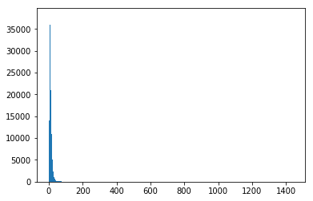

```python
bin_edges = np.arange(0, ford_bikes_clean['duration_min'].max()+1, 1)
plt.hist(data = ford_bikes_clean, x = 'duration_min',bins=bin_edges);
```

Seems like there are some outlieres, so i will use a logarithmic scale.

```python
ford_bikes_clean.duration_min.describe()
```

```
count    453159.000000
mean         13.882234
std          42.088012
min           1.016667
25%           6.066667
50%           9.266667
75%          13.966667
max        1437.533333
Name: duration_min, dtype: float64
```

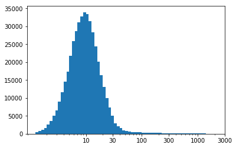

```python
bin_edges = 10** np.arange(0.1, np.log10(ford_bikes_clean['duration_min'].max())+0.05,0.05)
plt.hist(data = ford_bikes_clean, x = 'duration_min',bins=bin_edges);
plt.xscale('log')
tick_locs = [10, 30, 100, 300, 1000, 3000]
plt.xticks(tick_locs, tick_locs);
```

With the logarithmic scale, a normal distribution could be assumed, with the median arround 600 seconds equaling 10 minutes.

Next i will look at the rents over the different months.

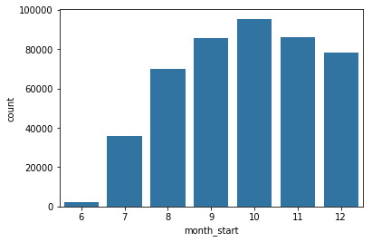

```python
# get proportion taken by most common group for derivation
# of tick marks
ford_bikes_clean['month_start']=ford_bikes_clean['start_time'].dt.month
base_color = sb.color_palette()[0]
sb.countplot(data = ford_bikes_clean, x = 'month_start', color = base_color)
```

Since the first month is June, i expect that the collecting of the data started at this time. This explains the strong rise in the first months, since it was newly introduced And the reduce in usage after octobre, because of the weather and winter.

Next: lets have a look at the day's of the week

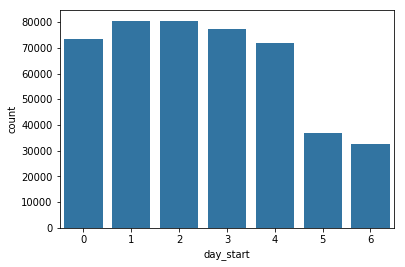

```python
base_color = sb.color_palette()[0]
ford_bikes_clean['day_start']=ford_bikes_clean['start_time'].dt.dayofweek
sb.countplot(data = ford_bikes_clean, x = 'day_start', color = base_color);
```

A lot more rents under the week compared to the weekend.

Next: lets have a look at the daytime of the rents

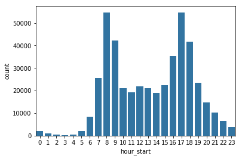

```python
ford_bikes_clean['hour_start']=ford_bikes_clean['start_time'].dt.hour
sb.countplot(data = ford_bikes_clean, x = 'hour_start', color = base_color);
```

Peeks between 8-9 and 17-18 correlating with rush hours and work beginnings/endings.

```python
ford_bikes_clean.info()
```

```
<class 'pandas.core.frame.DataFrame'>
Int64Index: 453159 entries, 0 to 519699
Data columns (total 18 columns):
duration_min               453159 non-null float64
start_time                 453159 non-null datetime64[ns]
end_time                   453159 non-null datetime64[ns]
start_station_id           453159 non-null int64
start_station_name         453159 non-null object
start_station_latitude     453159 non-null float64
start_station_longitude    453159 non-null float64
end_station_id             453159 non-null int64
end_station_name           453159 non-null object
end_station_latitude       453159 non-null float64
end_station_longitude      453159 non-null float64
bike_id                    453159 non-null int64
user_type                  453159 non-null object
member_birth_year          453159 non-null int32
member_gender              453159 non-null object
month_start                453159 non-null int64
day_start                  453159 non-null int64
hour_start                 453159 non-null int64
dtypes: datetime64[ns](2), float64(5), int32(1), int64(6), object(4)
memory usage: 84.0+ MB
```

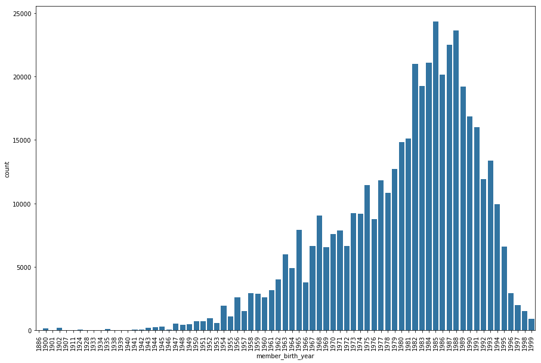

```python
plt.figure(figsize=[15, 10])
sb.countplot(data = ford_bikes_clean, x = 'member_birth_year', color = base_color);
plt.xticks(rotation=90);
```

The distribution of the member age is left skewed, which makes sense, since younger people are more likely to use the fordbikes. Also there are a few outliers, which should be wrong entries. (birth year 1900,1902)

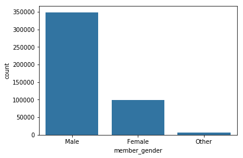

```python
sb.countplot(data = ford_bikes_clean, x = 'member_gender', color = base_color);
```

There are a lot more male user then female user. Probably this is a default value when you need to register for the services and therefore a wrong value

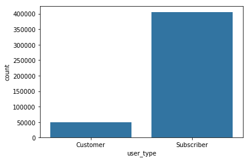

```python
sb.countplot(data = ford_bikes_clean, x = 'user_type', color = base_color);
```

There are a lot more subscribed than non subscribed users.

### Discuss the distribution(s) of your variable(s) of interest. Were there any unusual points? Did you need to perform any transformations?

- The distribution of the duration was heavily right skewed, since there are some outliers with extrem high renting durations. Under a log-scale the distribution appears normaly distributed.
- There are way more male users then female users. Since the majority of users are subscribers, it seems like this is actualy true and not just a wrong input due to laziniess. An even smaller percentage is from a nother gender

### Of the features you investigated, were there any unusual distributions? Did you perform any operations on the data to tidy, adjust, or change the form of the data? If so, why did you do this?

For tidieing look in the asses and clean steps above.

## Bivariate Exploration

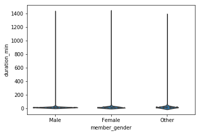

```python
sb.violinplot(data = ford_bikes_clean, x = 'member_gender', y = 'duration_min', color = base_color,
              inner = 'quartile')
```

Since there are a outliers, i will use the boxplot plot to display it better and cut of the y-axis and set it to a log scale

```
(1, 40)
```

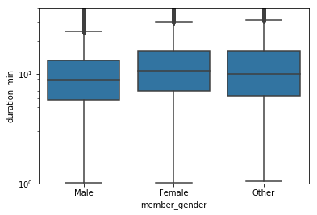

```python
sb.boxplot(data = ford_bikes_clean, x = 'member_gender', y = 'duration_min', color = base_color)
plt.yscale('log')
plt.ylim(1,40)
```

It seems like females and other genders are renting bikes slightly longer then males.

Lets have a look at the duration over the month

```
(1, 30)
```

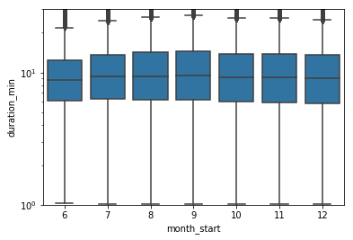

```python
sb.boxplot(data = ford_bikes_clean, x = 'month_start', y = 'duration_min', color = base_color)
plt.yscale('log')
plt.ylim(1,30)
```

Over the month, the average usage stayed a almost constant, peaking slightly around september.

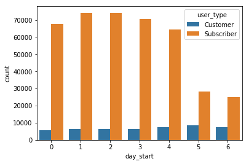

```python
sb.countplot(data = ford_bikes_clean, x = 'day_start', hue = 'user_type')
```

```
(1, 50)
```

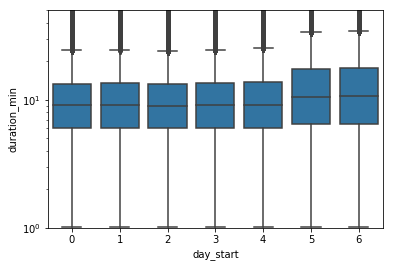

```python
sb.boxplot(data = ford_bikes_clean, x = 'day_start', y = 'duration_min', color = base_color)
plt.yscale('log')
plt.ylim(1,50)
```

Looking at this char, the average renting time increases slightly on the weekend compared to under the week.

```
(1, 50)
```

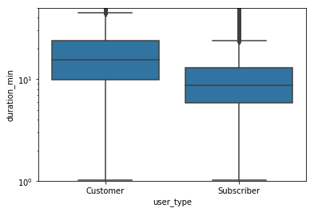

```python
sb.boxplot(data = ford_bikes_clean, x = 'user_type', y = 'duration_min', color = base_color)
plt.yscale('log')
plt.ylim(1,50)
```

And this graph states, that non subscribed customer take a much longer ride than subscribed customer.

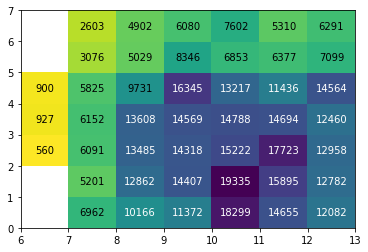

```python
# hist2d returns a number of different variables, including an array of counts
bins_y = np.arange(0, 8, 1)
bins_x = np.arange(6, 14, 1)
h2d = plt.hist2d(data = ford_bikes_clean, x = 'month_start', y = 'day_start',
               bins = [bins_x, bins_y], cmap = 'viridis_r', cmin = 0.5)
counts = h2d[0]

# loop through the cell counts and add text annotations for each
for i in range(counts.shape[0]):
    for j in range(counts.shape[1]):
        c = counts[i,j]
        if c >= 10000: # increase visibility on darkest cells
            plt.text(bins_x[i]+0.5, bins_y[j]+0.5, int(c),
                     ha = 'center', va = 'center', color = 'white')
        elif c > 0:
            plt.text(bins_x[i]+0.5, bins_y[j]+0.5, int(c),
                     ha = 'center', va = 'center', color = 'black')
```

The usage of the service under the week stays higher than on the weekend through out the year,

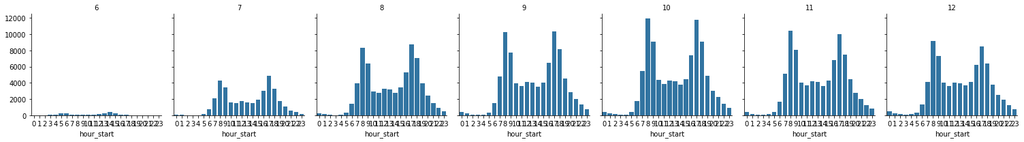

```python
g = sb.FacetGrid(data = ford_bikes_clean, col = 'month_start')
g.map(sb.countplot, 'hour_start')
g.set_titles('{col_name}')
```

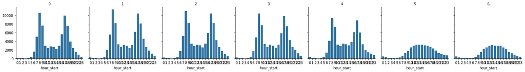

```python
g = sb.FacetGrid(data = ford_bikes_clean, col = 'day_start')
g.map(sb.countplot, 'hour_start')
g.set_titles('{col_name}')
```

How ever, if you look at the average renting hours of the day, you clearly see the two peaked distribution under the week, and the peak arround the midday on the weekends with lower usage in the morning and in the evening.

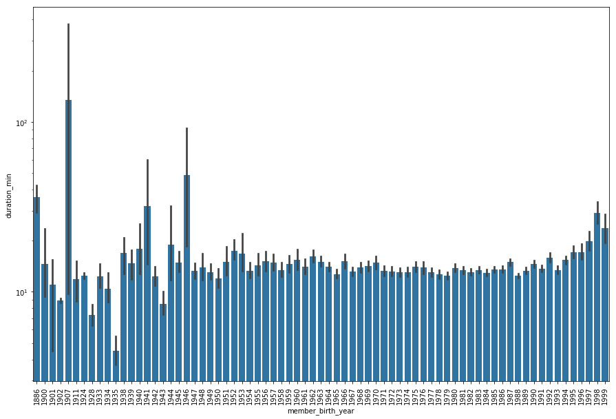

```python
plt.figure(figsize=[15, 10])
sb.barplot(data = ford_bikes_clean, x = 'member_birth_year',y='duration_min', color = base_color);
plt.yscale('log')
plt.xticks(rotation=90);
```

Besides the few outliers, the duration over the different ages, does not vary to much. There is a slight rise in duration if you look at younger people.

### Talk about some of the relationships you observed in this part of the investigation. How did the feature(s) of interest vary with other features in the dataset?

The hour of rental seems to correlate highly with the weekday. Also it seems that there are way more male users and that female users or users from a nother gender are taking slightly longer for their rides.

### Did you observe any interesting relationships between the other features (not the main feature(s) of interest)?

Younger people tend to rent the bike slightly longer than older people

## Multivariate Exploration

Next oi want to see if the daytime of renting changes over the months for the different days.

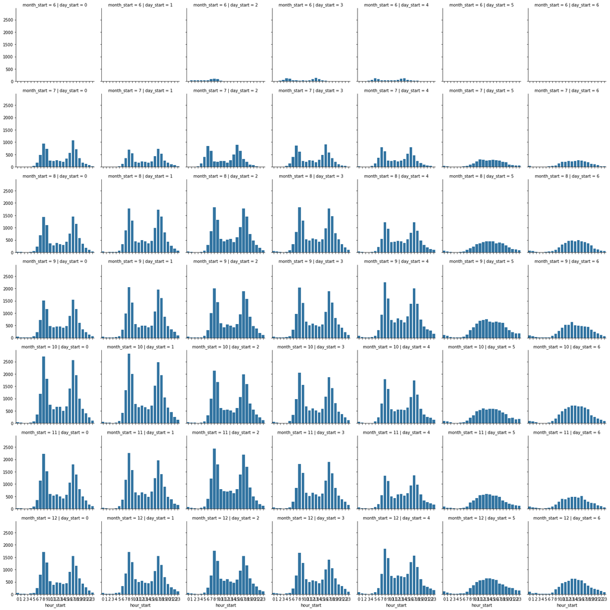

```python
g = sb.FacetGrid(data = ford_bikes_clean, col = 'day_start',row='month_start')
g.map(sb.countplot, 'hour_start');
```

It seems like the distribution for weekdays and weekend stays constant through out the months. Next i want to see if the daytime in combination with the month and the day of renting have an impact on the duration of the rent.

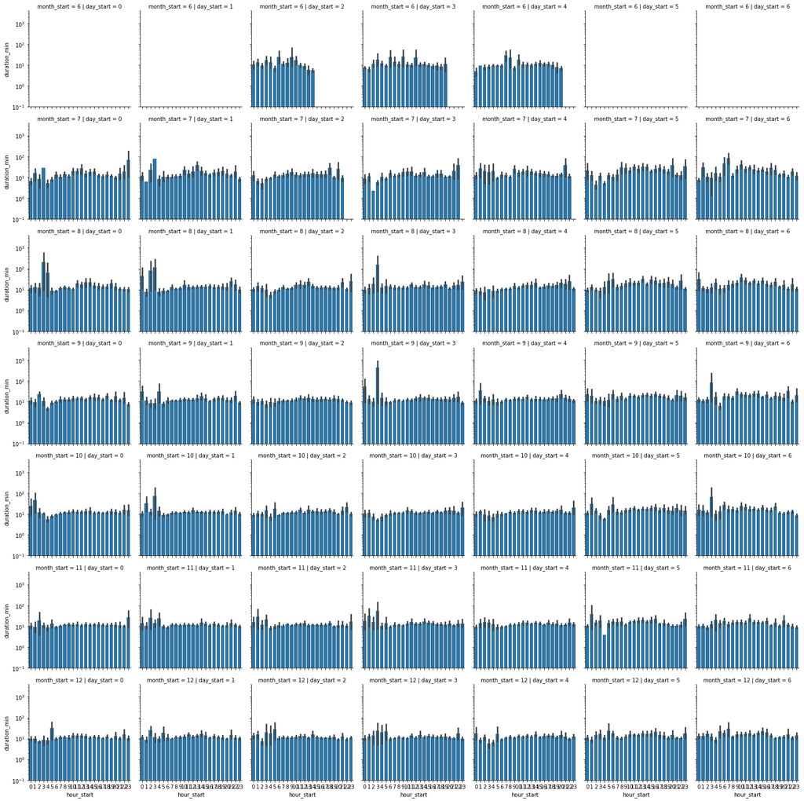

```python
g = sb.FacetGrid(data = ford_bikes_clean, col = 'day_start',row='month_start')
g.map(sb.barplot, 'hour_start','duration_min');
g.set(ylim=(0.1,4000),yscale=('log'));
```

The duration of the rent almost keeps constant througth out the hours and days of each month. However, lets have a more detailed look in the next graph

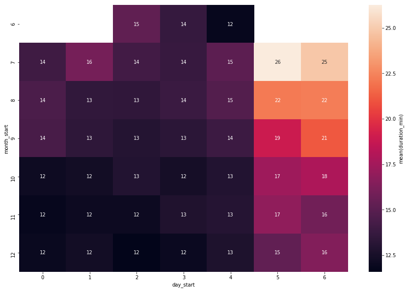

```python
plt.figure(figsize=[15, 10])
cat_means = ford_bikes_clean.groupby(['month_start', 'day_start']).mean()['duration_min']
cat_means = cat_means.reset_index(name = 'duration_min_avg')
cat_means = cat_means.pivot(index = 'month_start', columns = 'day_start',
                            values = 'duration_min_avg')
sb.heatmap(cat_means, annot = True,fmt = '.0f',
           cbar_kws = {'label' : 'mean(duration_min)'})
```

You can see, that the average rental time on the weekend ist 10 minutes longer on the weekend than under the week in the month july. With winter months coming, the duration of the rides over the weekend decreases, coming closer to the weekly average, to only be seperated by a few minutes. Let's have a look for the customer and subscriber average renting duration through out the week.

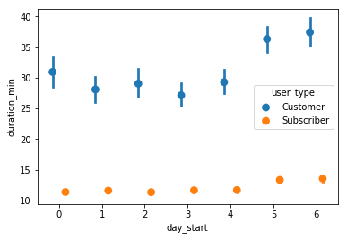

```python
ax = sb.pointplot(data = ford_bikes_clean, x = 'day_start', y = 'duration_min', hue = 'user_type',
                  dodge = 0.3, linestyles = "")
```

### Talk about some of the relationships you observed in this part of the investigation. Were there features that strengthened each other in terms of looking at your feature(s) of interest?

The duration of renting on the weekend increases dramatically, especially in the summer month. Also the duration of renting from non subscribed customers is significant longer compared to the one of subscribers.

### Were there any interesting or surprising interactions between features?

-

save clean dataset

```python
ford_bikes_clean.to_csv('ford_bikes_clean.csv',index=False)
```